# Hello Soft Clustering (GMM)

### T1. Using 3 mixtures, initialize your Gaussian with means (3,3), (2,2), and (-3,-3), and standard Covariance, I, the identity matrix. Use equal mix- ture weights as the initial weights. Repeat three iterations of EM. Write down $w_{n,j}$ , $m_j$ , $\vec{μ_j}$, $\Sigma_j$ for each EM iteration. (You may do the calculations by hand or write code to do so)

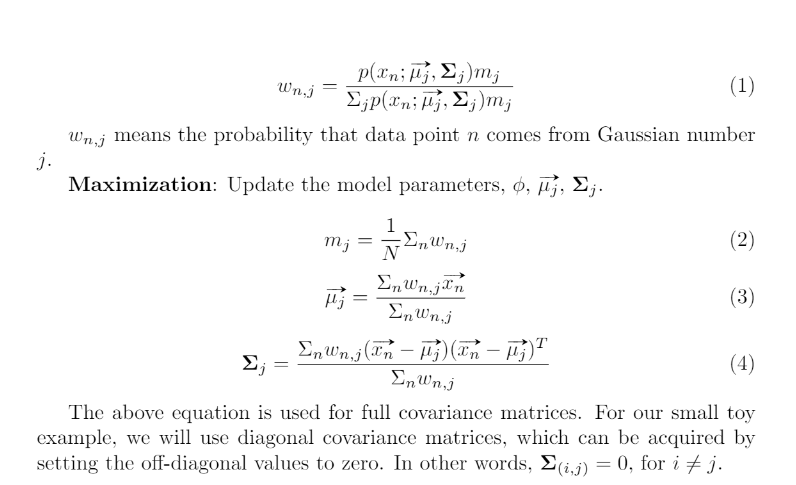

## TODO: Complete functions below including

- Fill relevant parameters in each function.
- Implement computation and return values.

These functions will be used in T1-4.

```python
import numpy as np
import matplotlib.pyplot as plt

# Hint: You can use this function to get gaussian distribution.
# https://docs.scipy.org/doc/scipy/reference/generated/scipy.stats.multivariate_normal.html
from scipy.stats import multivariate_normal
```

```python
class GMM:
    def __init__(self, mixture_weight, mean_params, cov_params):
        """
        Initialize GMM.
        """
        # Copy construction values.
        self.mixture_weight = mixture_weight
        self.mean_params = mean_params + 1e-20
        self.cov_params = cov_params + 1e-20

        # Initiailize iteration.
        self.n_iter = 0

    def estimation_step(self, data):
        """
        TODO: Perform estimation step. Then, return w_{n,j} in eq. 1)
        """


        # INSERT CODE HERE
        size = self.mean_params.shape[0]
        probability = []
        for i in range(size):
            probability += [multivariate_normal(mean = self.mean_params[i], cov=self.cov_params[i]).pdf(data)]
        probability = np.array(probability)

        probability_multiplied = np.eye(len(self.mixture_weight)) * self.mixture_weight @ probability

        w = probability_multiplied / np.sum(probability_multiplied, axis=0)
        return w


    def maximization_step(self, data, w):
        """
        TODO: Perform maximization step.
            (Update parameters in this GMM model.)
        """
        # INSERT CODE HERE

        size = data.shape[0]

        self.mixture_weight = (1/size)*np.sum(w, axis=1)
        self.mean_params = ((w @ data).T / (w.sum(axis=1)+1e-20)).T
        self.cov_params = np.array([np.dot((w[i].reshape(-1,1)*(data-self.mean_params[i])).T, (data-self.mean_params[i]))/(np.sum(w[i])+1e-20) for i in range(self.mean_params.shape[0])])
        self.cov_params = (self.cov_params+1e-20) * np.eye(self.cov_params.shape[1])


    def get_log_likelihood(self, data):
        """
        TODO: Compute log likelihood.
        """


        # INSERT CODE HERE
        size = self.mean_params.shape[0]
        probability = []
        for i in range(size):
            probability += [multivariate_normal(mean = self.mean_params[i], cov=self.cov_params[i]).pdf(data)*self.mixture_weight[i]]
        probability = np.array(probability)

        log_prob = np.log(np.array(probability).sum(axis=0)).sum()

        return log_prob

    def print_iteration(self):
        print("m :\n", self.mixture_weight)
        print("mu :\n", self.mean_params)
        print("covariance matrix :\n", self.cov_params)
        print("-------------------------------------------------------------")

    def perform_em_iterations(self, data, num_iterations, display=True):
        """
        Perform estimation & maximization steps with num_iterations.
        Then, return list of log_likelihood from those iterations.
        """
        log_prob_list = []

        # Display initialization.
        if display:
            print("Initialization")
            self.print_iteration()

        for n_iter in range(num_iterations):

            # TODO: Perform EM step.

            # INSERT CODE HERE
            w = self.estimation_step(data)
            self.maximization_step(data, w)


            # Calculate log prob.
            log_prob = self.get_log_likelihood(data)
            log_prob_list.append(log_prob)

            # Display each iteration.
            if display:
                print(f"Iteration: {n_iter}")
                self.print_iteration()

        return log_prob_list
```

```python
num_iterations = 3
num_mixture = 3
mixture_weight = [1] * num_mixture # m
mean_params = np.array([[3,3], [2,2], [-3,-3]], dtype = float)
cov_params = np.array([np.eye(2)] * num_mixture)

X, Y = np.array([1, 3, 2, 8, 6, 7, -3, -2, -7]), np.array([2, 3, 2, 8, 6, 7, -3, -4, -7])
data = np.vstack([X,Y]).T

gmm = GMM(mixture_weight, mean_params, cov_params)
log_prob_list = gmm.perform_em_iterations(data, num_iterations)
```

```
Initialization
m :
 [1, 1, 1]
mu :
 [[ 3.  3.]
 [ 2.  2.]
 [-3. -3.]]
covariance matrix :
 [[[1.e+00 1.e-20]
  [1.e-20 1.e+00]]

 [[1.e+00 1.e-20]
  [1.e-20 1.e+00]]

 [[1.e+00 1.e-20]
  [1.e-20 1.e+00]]]
-------------------------------------------------------------
Iteration: 0
m :
 [0.45757242 0.20909425 0.33333333]
mu :
 [[ 5.78992692  5.81887265]
 [ 1.67718211  2.14523106]
 [-4.         -4.66666666]]
covariance matrix :
 [[[4.53619412 0.        ]
  [0.         4.28700611]]

 [[0.51645579 0.        ]
  [0.         0.13152618]]

 [[4.66666668 0.        ]
  [0.         2.88888891]]]
-------------------------------------------------------------
Iteration: 1
m :
 [0.40711618 0.25954961 0.33333421]
mu :
 [[ 6.27176215  6.27262711]
 [ 1.72091544  2.14764812]
```

[output cut: 13 more lines]

```
 [0.36070909 0.30595677 0.33333414]
mu :
 [[ 6.6962644   6.69629468]
 [ 1.91071238  2.27383436]
 [-3.99998673 -4.6666501 ]]
covariance matrix :
 [[[1.73961067 0.        ]
  [0.         1.73929602]]

 [[0.62898406 0.        ]
  [0.         0.1988491 ]]

 [[4.66672942 0.        ]
  [0.         2.88899545]]]
-------------------------------------------------------------
```

### T2. Plot the log likelihood of the model given the data after each EM step. In other words, plot $\log \prod_n p( \vec{x_n} |φ, \vec{μ} , Σ)$. Does it goes up every iteration just as we learned in class?

[figure not shown]

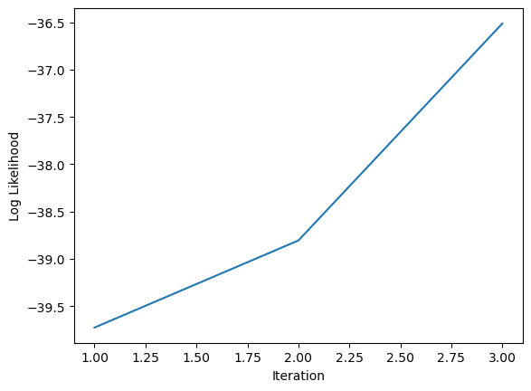

```python
def plot_log_likelihood(log_prob_list, num_iterations):
    plt.figure()
    plt.plot(range(1, num_iterations + 1), log_prob_list)
    plt.xlabel('Iteration')
    plt.ylabel('Log Likelihood')
    plt.show()

plot_log_likelihood(log_prob_list, num_iterations)
```

```
ANS : Yes, it increases after each iteration.
```

### T3. Using 2 mixtures, initialize your Gaussian with means (3,3) and (-3,-3), and standard Covariance, I, the identity matrix. Use equal mixture weights as the initial weights. Repeat three iterations of EM. Write down $w_{n,j}$ , $m_j$ , $\vec{μ_j}$, $\Sigma_j$ for each EM iteration.

```python
num_mixture = 2
mixture_weight = [1] * num_mixture

mean_params = np.array([[3,3], [-3,-3]], dtype = float)
cov_params = np.array([np.eye(2)] * num_mixture)

# INSERT CODE HERE
gmm2 = GMM(mixture_weight=mixture_weight, mean_params=mean_params, cov_params=cov_params)
log_prob_list2 = gmm2.perform_em_iterations(data, num_iterations)
```

```
Initialization
m :
 [1, 1]
mu :
 [[ 3.  3.]
 [-3. -3.]]
covariance matrix :
 [[[1.e+00 1.e-20]
  [1.e-20 1.e+00]]

 [[1.e+00 1.e-20]
  [1.e-20 1.e+00]]]
-------------------------------------------------------------
Iteration: 0
m :
 [0.66666666 0.33333334]
mu :
 [[ 4.50000001  4.66666667]
 [-3.99999997 -4.66666663]]
covariance matrix :
 [[[6.91666665 0.        ]
  [0.         5.88888889]]

 [[4.66666677 0.        ]
  [0.         2.8888891 ]]]
-------------------------------------------------------------
Iteration: 1
m :
 [0.66669436 0.33330564]
mu :
 [[ 4.49961311  4.66620178]
 [-3.99993241 -4.66651231]]
covariance matrix :
 [[[6.91944755 0.        ]
  [0.         5.89275124]]

 [[4.66806942 0.        ]
  [0.         2.89103318]]]
-------------------------------------------------------------
Iteration: 2
m :
 [0.66669453 0.33330547]
mu :
 [[ 4.49961084  4.66619903]
 [-3.99993206 -4.66651141]]
covariance matrix :
 [[[6.91946372 0.        ]
  [0.         5.8927741 ]]

 [[4.66807754 0.        ]
  [0.         2.89104566]]]
-------------------------------------------------------------
```

### T4. Plot the log likelihood of the model given the data after each EM step. Compare the log likelihood between using two mixtures and three mixtures. Which one has the better likelihood?

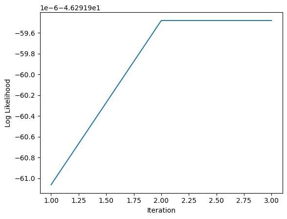

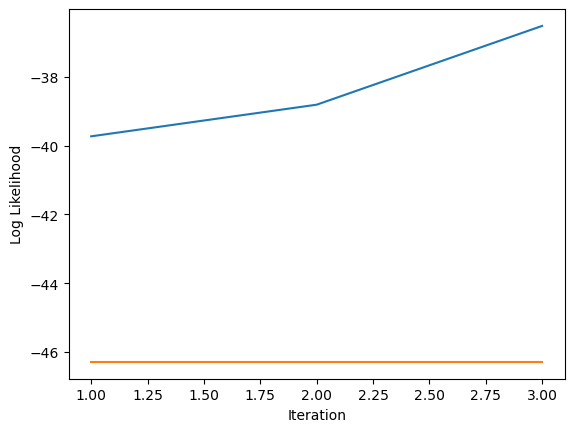

```python
# TODO: Plot log_likelihood from T3
plot_log_likelihood(log_prob_list2, num_iterations)

# TODO: Plot Comparision of log_likelihood from T1 and T3

plt.figure()
plt.plot(range(1, num_iterations + 1), log_prob_list)
plt.plot(range(1, num_iterations + 1), log_prob_list2)
plt.xlabel("Iteration")
plt.ylabel("Log Likelihood")
plt.show()
```

```
ANS : The model with 3 mixtures performs better as it achieves a higher log-likelihood.
```

# The face database

```python
# Download facedata for google colab
# !wget -nc https://github.com/ekapolc/Pattern_2024/raw/main/HW/HW03/facedata_mat.zip
# !unzip facedata_mat.zip
```

```python
import scipy.io
import numpy as np
import matplotlib.pyplot as plt
import matplotlib.image as mpimg
from skimage import img_as_float

# Change path to your facedata.mat file.
facedata_path = 'facedata.mat'

data = scipy.io.loadmat(facedata_path)
data_size = data['facedata'].shape

%matplotlib inline
data_size
```

```
(40, 10)
```

### Preprocess xf

```python
xf = np.zeros((data_size[0], data_size[1], data['facedata'][0,0].shape[0], data['facedata'][0,0].shape[1]))
for i in range(data['facedata'].shape[0]):
    for j in range(data['facedata'].shape[1]):
        xf[i,j] = img_as_float(data['facedata'][i,j])
```

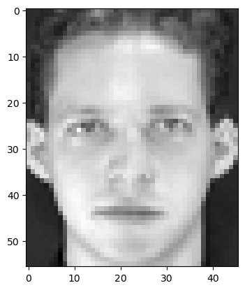

```python
# ex: ploting face image.
plt.imshow(xf[0,0], cmap = 'gray')
plt.show()
```

### T5. What is the Euclidean distance between xf[0,0] and xf[0,1]? What is the Euclidean distance between xf[0,0] and xf[1,0]? Does the numbers make sense? Do you think these numbers will be useful for face verification?

```python
def L2_dist(vector1, vector2):
    """
    TODO: Calculate L2 distance.
    """
    return np.sqrt( ((vector1-vector2)**2).sum() )

# Test L2_dist
def test_L2_dist():
    assert L2_dist(np.array([1, 2, 3]), np.array([1, 2, 3])) == 0.0
    assert  L2_dist(np.array([0, 0, 0]), np.array([1, 2, 3])) == np.sqrt(14)

test_L2_dist()

print('Euclidean distance between xf[0,0] and xf[0,1] is', L2_dist(xf[0,0], xf[0,1]))
print('Euclidean distance between xf[0,0] and xf[1,0] is', L2_dist(xf[0,0], xf[1,0]))
```

```
Euclidean distance between xf[0,0] and xf[0,1] is 10.037616294165492
Euclidean distance between xf[0,0] and xf[1,0] is 8.173295099737281
```

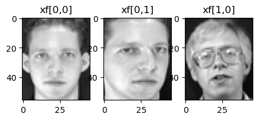

```python
# TODO: Show why does the numbers make sense
fig, axes = plt.subplots(1, 3,figsize=(5, 3))
axes[0].imshow(xf[0,0], cmap = 'gray')
axes[0].set_title('xf[0,0]')
axes[1].imshow(xf[0,1], cmap = 'gray')
axes[1].set_title('xf[0,1]')
axes[2].imshow(xf[1,0], cmap = 'gray')
axes[2].set_title('xf[1,0]')
plt.show()
```

Ans: The xf[1,0] is more similiar to the original than the xf[0, 1].

### T6. Write a function that takes in a set of feature vectors T and a set of feature vectors D, and then output the similarity matrix A. Show the matrix as an image. Use the feature vectors from the first 3 images from all 40 people for list T (in order x[0, 0], x[0, 1], x[0, 2], x[1, 0], x[1, 1], ...x[39, 2]). Use the feature vectors from the remaining 7 images from all 40 people for list D (in order x[0, 3], x[0, 4], x[0, 5], x[1, 6], x[0, 7], x[0, 8], x[0, 9], x[1, 3], x[1, 4]...x[39, 9]). We will treat T as our training images and D as our testing images

```python
def organize_shape(input_data):
    """
    TODO (Optional): Reduce matrix dimension of 2D image to 1D and merge people and image dimension.
    This function can be useful at organizing matrix shapes.

    Example:
        Input shape: (people_index, image_index, image_shape[0], image_shape[1])
        Output shape: (people_index*image_index, image_shape[0]*image_shape[1])
    """
    new_mat = input_data.copy()
    new_row, new_col = (
        new_mat.shape[0] * new_mat.shape[1],
        new_mat.shape[2] * new_mat.shape[3],
    )
    new_mat = new_mat.reshape((new_row, new_col))
    return new_mat


def generate_similarity_matrix(set1, set2):
    """
    TODO: Calculate similarity matrix M,
    which M[i, j] is a distance between set1[i] and set2[j].
    """

    # INSERT CODE HERE
    sim_mat = np.zeros((set1.shape[0], set2.shape[0]))
    for i in range(set1.shape[0]):
        for j in range(set2.shape[0]):
            sim_mat[i][j] = L2_dist(set1[i], set2[j])
    return sim_mat

def test_gen_sim_mat():
    test_A = np.array([[1, 2],[3,4]])
    test_B = np.array([[1, 2], [5, 6], [7, 8]])
    expected_matrix = np.sqrt(np.array([[0, 32, 72], [8, 8, 32]]))
    assert (generate_similarity_matrix(test_A, test_B) == expected_matrix).all()

test_gen_sim_mat()
```

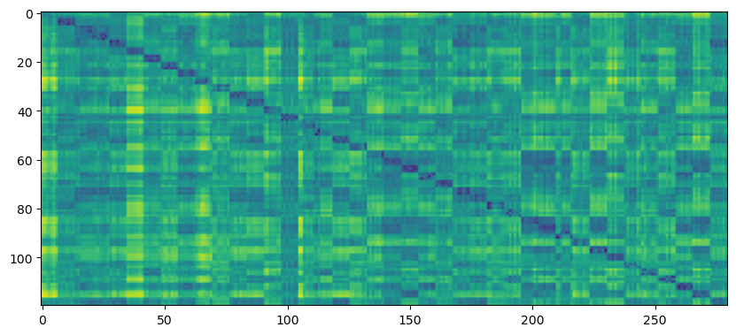

```python
# TODO: Show similariry matrix between T and D.

# INSERT CODE HERE
T = organize_shape(xf[:, :3])
D = organize_shape(xf[:, 3:])

sim_mat = generate_similarity_matrix(T, D)

plt.figure(figsize=(10, 10))
plt.imshow(sim_mat)
plt.show()
```

### T7. From the example similarity matrix above, what does the black square between [5:10,5:10] suggest about the pictures from person number 2? What do the patterns from person number 1 say about the images from person 1?

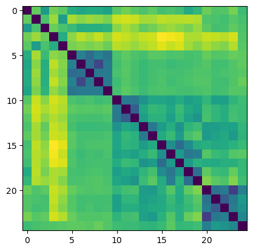

```python
# INSERT CODE HERE

new_T = organize_shape(xf[:5, :5])

plt.imshow(generate_similarity_matrix(new_T, new_T))
plt.show()
```

[output not shown]

### T8. Write a function that takes in the similarity matrix created from the previous part, and a threshold t as inputs. The outputs of the function are the true positive rate and the false alarm rate of the face verification task (280 Test images, tested on 40 people, a total of 11200 testing per threshold). What is the true positive rate and the false alarm rate for t = 10?

```python
def evaluate_performance(similarity_matrix, decision_threshold):
    """
    TODO: Calculate true positive rate and false alarm rate from given similarity_matrix and decision_threshold.
    """

    # INSERT CODE HERE
    predictions = np.zeros((40, 280))
    ground_truth = np.zeros((40, 280))
    for i in range(40):
        for j in range(280):
            predictions[i, j] = similarity_matrix[3*i:3*i+3, j].min() < decision_threshold
            ground_truth[i, j] = i == j//7

    tp = np.where(predictions==ground_truth, predictions, 0).sum()
    tn = np.where(predictions==ground_truth, 1-predictions, 0).sum()
    fp = np.where(predictions!=ground_truth, 1-ground_truth, 0).sum()
    fn = np.where(predictions!=ground_truth, ground_truth, 0).sum()

    true_pos_rate = tp/(tp+fn)
    false_positive_rate = fp/(tn+fp)
    false_neg_rate=fn/(tp+fn)
    true_neg_rate=tn/(tn+fp)
    return true_pos_rate, false_positive_rate, false_neg_rate, true_neg_rate

# Quick check
# (true_pos_rate, false_neg_rate) should be (0.9928571428571429, 0.33507326007326005)
evaluate_performance(similarity_matrix, 9.5)
```

```
(1.0, 1.0, 0.0, 0.0)
```

```python
# INSERT CODE HERE

evaluate_performance(similarity_matrix, 10)
```

```
(1.0, 1.0, 0.0, 0.0)
```

### T9. Plot the RoC curve for this simple verification system. What should be the minimum threshold to generate the RoC curve? What should be the maximum threshold? Your RoC should be generated from at least 1000 threshold levels equally spaced between the minimum and the maximum. (You should write a function for this).

```python
def calculate_roc(similarity_matrix):
    """
    TODO: Calculate a list of true_pos_rate and a list of false_neg_rate from the given matrix.
    """

    # INSERT CODE HERE
    tpr_list, fpr_list, fnr_list, tnr_list=[],[],[],[]

    for threshold in np.linspace(np.min(similarity_matrix), np.max(similarity_matrix), num=1000):
        tpr, fpr, fnr, tnr = evaluate_performance(similarity_matrix, threshold)

        tpr_list.append(tpr)
        fpr_list.append(fpr)
        fnr_list.append(fnr)
        tnr_list.append(tnr)

    tpr_list = np.array(tpr_list)
    fpr_list = np.array(fpr_list)
    fnr_list = np.array(fnr_list)
    tnr_list = np.array(tnr_list)

    return tpr_list, fpr_list, fnr_list, tnr_list

tpr_list, fpr_list, fnr_list, tnr_list=np.array([]),np.array([]),np.array([]),np.array([])


def plot_roc(similarity_matrix, label=None, show_plot=None):
    """
    TODO: Plot RoC Curve from a given matrix.
    """
    # INSERT CODE HERE
    global tpr_list,fpr_list,fnr_list,tnr_list

    tpr_list, fpr_list, fnr_list, tnr_list = calculate_roc(similarity_matrix)

    if label:
        plt.plot(fpr_list, tpr_list, label=label)
    else:
        plt.plot(fpr_list, tpr_list)
    plt.plot(fpr_list, tpr_list)
    plt.xlabel('False Alarm Rate (FAR)')
    plt.ylabel('True Positive Rate (TPR)')
    plt.title('Receiver Operating Characteristic (ROC) Curve')
    if show_plot == None:
        plt.show()

    return fnr_list
```

[figure not shown]

[output not shown]

[output cut: 145 more lines]

[output not shown]

```python
# INSERT CODE HERE

tpr_list,fpr_list,fnr_list,tnr_list=np.array([]),np.array([]),np.array([]),np.array([])

plot_roc(similarity_matrix)
```

ANS: The minimum threshold should be the minimum value in the similarity matrix, and the maximum threshold should be the maximum value in the similarity matrix.

### T10. What is the EER (Equal Error Rate)? What is the recall rate at 0.1% false alarm rate? (Write this in the same function as the previous question)

```python
# You can add more parameter(s) to the function in the previous question.

# EER should be either 0.9071428571428571 or 0.9103759398496248 depending on method.
# Recall rate at 0.1% false alarm rate should be 0.5428571428571428.

print("EER :",tpr_list[np.argmin(np.abs(fpr_list - fnr_list))])
print("Recall at 0.001 false neg :",tpr_list[np.argmin(np.abs(fpr_list - 0.001))])
```

[output not shown]

### T11. Compute the mean vector from the training images. Show the vector as an image (use numpy.reshape()). This is typically called the meanface (or meanvoice for speech signals). You answer should look exactly like the image shown below.

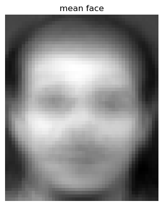

```python
# INSERT CODE HERE
mean_face_vector = np.mean(T.reshape(120,56*46),axis=0)

plt.title('mean face')
plt.axis('off')
plt.imshow(mean_face_vector.reshape(56, 46), cmap='gray')
plt.show()
```

### T12. What is the size of the covariance matrix? What is the rank of the covariance matrix?

```python
# TODO: Find the size and the rank of the covariance matrix.
print("size: ",T.shape[1], T.shape[1])
print("rank: ", min(T.shape[1], T.shape[0] - 1))
```

```
size:  2576 2576
rank:  119
```

ANS: Size: (2576, 2576), Rank: 119 (min(N, d) - 1).

### T13. What is the size of the Gram matrix? What is the rank of Gram matrix? If we compute the eigenvalues from the Gram matrix, how many non- zero eigenvalues do we expect to get?

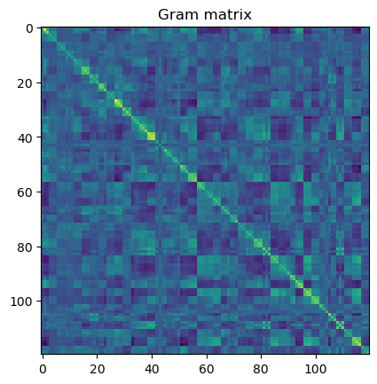

```python
# TODO: Compute gram matrix.
gram = np.matmul(T-mean_face_vector, (T-mean_face_vector).T)

plt.title(f'Gram matrix')
plt.imshow(gram)
plt.show()
```

```python
# TODO: Show size and rank of Gram matrix.

print("ANS:")
print("size", gram.shape)
print("rank", gram.shape[0])
print("non-zero eigenvalues", gram.shape[0]-1)
```

[output not shown]

## T14. Is the Gram matrix also symmetric? Why?

ANS: Yes, because it is computed as $X X^T$, and $(X X^T)^T = (X^T)^T X^T = X X^T$.

### T15. Compute the eigenvectors and eigenvalues of the Gram matrix, v 0 and λ. Sort the eigenvalues and eigenvectors in descending order so that the first eigenvalue is the highest, and the first eigenvector corresponds to the best direction. How many non-zero eigenvalues are there? If you see a very small value, it is just numerical error and should be treated as zero.

```python
# Hint: https://numpy.org/doc/stable/reference/generated/numpy.linalg.eigh.html

def calculate_eigs(input_matrix):
    """
    TODO: Calculate eigenvectors and eigenvalues,
    then sort the eigenvalues and eigenvectors in descending order.

    Hint: https://numpy.org/doc/stable/reference/generated/numpy.linalg.eigh.html
    """

    # INSERT CODE HERE
    vals, vecs = np.linalg.eigh(input_matrix)
    vals = vals[::-1]
    vecs = vecs[:, ::-1]

    return vals, vecs

evals, evecs = calculate_eigs(gram)

def test_eigenvalues_eigenvectors():
    # Dot product of an eigenvector pair should equal to zero.
    assert np.round(evecs[10].dot(evecs[20]), 10) == 0.0

    # Check if eigenvalues are sorted.
    assert list(evals) == sorted(evals, reverse = True)

test_eigenvalues_eigenvectors()
```

```python
gram_eigenvalues, gram_eigenvectors = calculate_eigenvectors_and_eigenvalues(
    gram_matrix
)
print("ANS:")
print("non-zero eigenvalues of gram matrix", np.sum(gram_eigenvalues > 1e-2))
print("shape gram_eigenvalues", gram_eigenvalues.shape)
print("Shape gram_eigenvectors", gram_eigenvectors.shape)
```

```
ANS:
non-zero eigenvalues of gram matrix 119
shape gram_eigenvalues (120,)
Shape gram_eigenvectors (120, 120)
```

### T16. Plot the eigenvalues. Observe how fast the eigenvalues decrease. In class, we learned that the eigenvalues is the size of the variance for each eigenvector direction. If I want to keep 95% of the variance in the data, how many eigenvectors should I use?

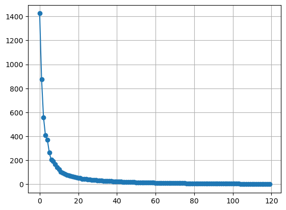

```
64
```

```python
# INSERT CODE HERE
gram_evals, gram_evecs = calculate_eigs(gram)
plt.plot(np.arange(len(evals)),evals,"-",marker="o")
plt.grid(True)
plt.show()

total_var = gram_evals.sum()

idx = 0
curr_var = 0
while curr_var < total_var*0.95 or idx >= len(gram_evals):
    curr_var += gram_evals[idx]
    idx += 1
print(idx)
```

ANS: We need about 64 eigenvectors to keep 95% of the variance.

```python
# TODO: Compute v, then renormalize it.

# INSERT CODE HERE
X_train = T.reshape(120,-1).T
X_centered = X_train - mean_face_vector.reshape(-1,1)

u = X_centered @ evecs
u /= np.linalg.norm(u, axis=0)
```

```python
def test_eignevector_cov_norm(v):
    assert (np.round(np.linalg.norm(v, axis=0), 1) == 1.0).all()

test_eignevector_cov_norm(u)
```

```python
# TODO: Show the first 10 eigenvectors as images.
plt.figure(figsize=(10, 5))
for i in range(10):
    plt.subplot(2, 5, i+1)
    plt.title("eigenface "+str(i))
    plt.imshow(u[:, i].reshape(56,46), cmap='gray')
    plt.show()
```

[output not shown]

### T18. From the image, what do you think the first eigenvector captures? What about the second eigenvector? Look at the original images, do you think biggest variance are capture in these two eigenvectors?

ANS: The first eigenvector likely captures the most significant variations like lighting or hairstyle. The second might capture other facial features like eyes or mouth shape. They likely capture the largest variance, but not necessarily all specific facial details.

### T19. Find the projection values of all images. Keep the first k = 10 projection values. Repeat the simple face verification system we did earlier using these projected values. What is the EER and the recall rate at 0.1% FAR?

```python
def calculate_projection_vectors(input_data, mean_vector, eigenvectors, num_components=None):
    """
    TODO: Find the projection vectors on v from given matrix and meanface.
    """

    # INSERT CODE HERE
    if num_components is None:
        proj_vecs = np.matmul(input_data - mean_vector, eigenvectors[:, :])
    else:
        proj_vecs = np.matmul(input_data - mean_vector, eigenvectors[:, :num_components])

    return proj_vecs
```

```python
# TODO: Get projection vectors of T and D, then Keep first k projection values.
k = 10
train_proj = calculate_projection_vectors(T, mean_face_vector, u)[:, :k]
test_proj = calculate_projection_vectors(D, mean_face_vector, u)[:, :k]


def test_reduce_dimension():
    assert train_proj.shape[-1] == k
    assert test_proj.shape[-1] == k

test_reduce_dimension()
```

```python
# TODO: Get similarity matrix of T_reduced and D_reduced
reduced_sim_matrix = generate_similarity_matrix(train_proj, test_proj)
```

[figure not shown]

```
ANS:
EER 0.9214285714285714
Recall 0.5178571428571429
```

```python
# TODO: Find EER and the recall rate at 0.1% FAR.
plot_roc(reduced_sim_matrix)

print("ANS:")
print("EER",tpr_list[np.argmin(np.abs(fpr_list - fnr_list))])
print("Recall",tpr_list[np.argmin(np.abs(fpr_list - 0.001))])
```

### T20. What is the k that gives the best EER? Try k = 5, 6, 7, 8, 9, 10, 11, 12, 13, 14.

```python
# INSERT CODE HERE
k_values = list(range(5, 15))
train_full_proj = calculate_projection_vectors(T, mean_face_vector, u)
test_full_proj = calculate_projection_vectors(D, mean_face_vector, u)
eer_values = []

for k in k_values:
    print("k", k)
    sim_mat_k = generate_similarity_matrix(train_full_proj[:,:k], test_full_proj[:,:k])
    tpr_list, fpr_list, fnr_list, tnr_list = calculate_roc(sim_mat_k)
    current_eer = tpr_list[np.argmin(np.abs(fpr_list - fnr_list))]
    print("EER", current_eer)
    eer_values.append(current_eer)
    print("Recall", tpr_list[np.argmin(np.abs(fpr_list - 0.001))])
    print()

plt.plot(k_values, eer_values)
plt.xlabel("number of eigenvectors")
plt.ylabel("EER")
```

```
k 5
EER 0.8928571428571429
Recall 0.25357142857142856

k 6
EER 0.9071428571428571
Recall 0.35

k 7
EER 0.9071428571428571
Recall 0.4107142857142857

k 8
EER 0.9142857142857143
Recall 0.40714285714285714

k 9
EER 0.9178571428571428
Recall 0.45

k 10
EER 0.9214285714285714
Recall 0.5178571428571429

k 11
EER 0.9214285714285714
Recall 0.5035714285714286

k 12
EER 0.9142857142857143
Recall 0.5107142857142857

k 13
EER 0.9142857142857143
Recall 0.5142857142857142

k 14
EER 0.9178571428571428
Recall 0.5035714285714286
```

```
ANS: k=10 or 11 gives the best EER.
```

### T21. In order to assure that $S_W$ is invertible we need to make sure that $S_W$ is full rank. How many PCA dimensions do we need to keep in order for $S_W$ to be full rank? (Hint: How many dimensions does $S_W$ have? In order to be of full rank, you need to have the same number of linearly independent factors)

```
ANS: We need N - C = 120 - 40 = 80 dimensions.
```

```python
# TODO: Define dimension of PCA.
n_components = T.shape[0] - 40
print("Dimension", n_components)

# TODO: Find PCA of T and D with n_dim dimension.
train_pca = calculate_projection_vectors(T, mean_face_vector, u, n_components)
test_pca = calculate_projection_vectors(D, mean_face_vector, u, n_components)
print(train_pca.shape, test_pca.shape)
```

```
Dimension 80
(120, 80) (280, 80)
```

### T22. Using the answer to the previous question, project the original in- put to the PCA subspace. Find the LDA projections. To find the inverse, use −1 numpy.linalg.inv. Is $S_W$ $S_B$ symmetric? Can we still use numpy.linalg.eigh? How many non-zero eigenvalues are there?

```
LDA is symmetric False
```

[figure not shown]

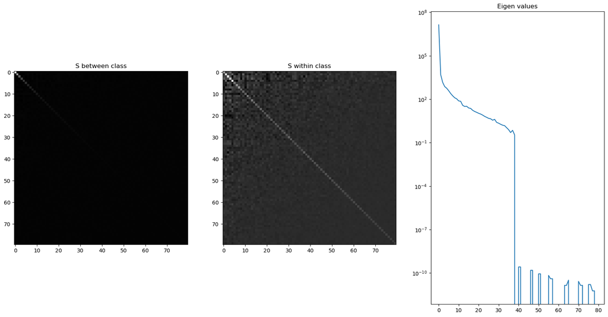

```python
# TODO: Find the LDA projection.
train_pca_by_class = train_pca.reshape((40, 3, -1))
means_by_class = train_pca_by_class.mean(axis=1)
global_mean = means_by_class.mean(axis=0).reshape(1, -1)

SB = np.array([(means_by_class[i]-global_mean).T @ (means_by_class[i]-global_mean) for i in range(means_by_class.shape[0])]).sum(axis=0)

SW_i = np.array([(train_pca_by_class[i]-means_by_class[i]).T @ (train_pca_by_class[i]-means_by_class[i]) for i in range(means_by_class.shape[0])])
SW = SW_i.sum(axis=0)

W_lda = np.linalg.inv(SW) @ SB
print("LDA is symmetric", np.allclose(W_lda, W_lda.T))
lda_evals, lda_evecs = np.linalg.eig(W_lda)

lda_evecs = lda_evecs.real
lda_evals = lda_evals.real

plt.figure(figsize=(20, 10))
plt.subplot(1, 3, 1)
plt.imshow(SB, cmap='gray')
plt.title("S between class")
plt.subplot(1, 3, 2)
plt.imshow(SW, cmap='gray')
plt.title("S within class")
plt.subplot(1, 3, 3)
plt.title("Eigen values")
plt.plot(lda_evals)
plt.yscale('log')

plt.show()
```

```python
# TODO: Find how many non-zero eigenvalues there are.

np.where(lda_evals > 1e-20, 1, 0).sum()
```

```
58
```

### T23. Plot the first 10 LDA eigenvectors as images (the 10 best projections). Note that in this setup, you need to convert back to the original image space by using the PCA projection. The LDA eigenvectors can be considered as a linear combination of eigenfaces. Compare the LDA projections with the PCA projections.

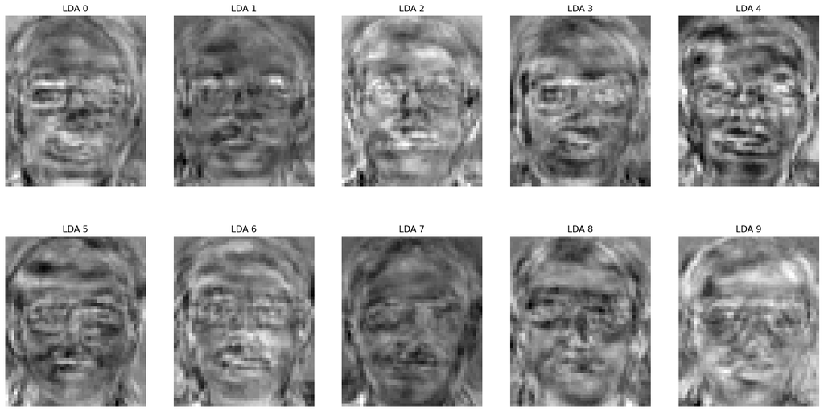

```python
# INSERT CODE HERE

best_10_lda_vecs = lda_evecs[:, :10]
train_lda = np.matmul(train_pca, best_10_lda_vecs)
eigenfaces_lda = np.matmul(u[:, :n_components], best_10_lda_vecs)

test_lda = np.matmul(test_pca, best_10_lda_vecs)

plt.figure(figsize=(20, 10))
for idx in range(10):
    plt.subplot(2, 5, idx+1)
    plt.imshow(eigenfaces_lda[:, idx].reshape(56, 46), cmap='gray')
    plt.title(f"LDA {idx}")
    plt.axis('off')

plt.show()
```

### T24. The combined PCA+LDA projection procedure is called fisherface. Calculate the fisherfaces projection of all images. Do the simple face verification experiment using fisherfaces. What is the EER and recall rate at 0.1% FAR?

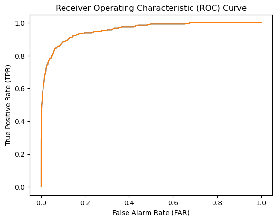

```
ANS:
EER 0.8857142857142857
Recall 0.40714285714285714
```

```python
# INSERT CODE HERE
fisher_sim_matrix = generate_similarity_matrix(train_lda, test_lda)
plot_roc(fisher_sim_matrix)

print("ANS:")
print("EER", tpr_list[np.argmin(np.abs(fpr_list - fnr_list))])
print("Recall", tpr_list[np.argmin(np.abs(fpr_list - 0.001))])
```

### T25.Plot the RoC of all three experiments (No projection, PCA, andFisher) on the same axes. Compare and contrast the three results. Submit yourwriteup and code on MyCourseVille.

```
Original
EER 0.9071428571428571
Recall 0.5428571428571428

PCA
EER 0.9214285714285714
Recall 0.5178571428571429

Fisherfaces
EER 0.8857142857142857
Recall 0.40714285714285714
```

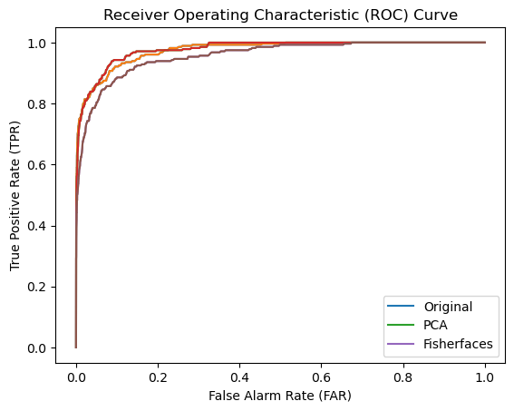

```python
# INSERT CODE HERE

experiments = {
    'Original': (T, D),
    'PCA': (train_proj, test_proj),
    'Fisherfaces': (train_lda, test_lda)
}

for label, (curr_train, curr_test) in experiments.items():
    sim_matrix = generate_similarity_matrix(curr_train, curr_test)
    plot_roc(sim_matrix, label=label, show_plot=False)

    print(label)
    print("EER",tpr_list[np.argmin(np.abs(fpr_list - fnr_list))])
    print("Recall",tpr_list[np.argmin(np.abs(fpr_list - 0.001))])
    print()

plt.legend()
plt.show()
```